# Comparison of more than 2 groups

2023-09-29

```r
amess = read.csv('amess.csv', header = TRUE)
amess$treatmnt <- factor(amess$treatmnt, levels = 1:3, labels = c("50% N2O and 50% O2 continuously for 24 hours", "50% N2O and 50% O2 during the operation", "No N2O but 35-50% O2 continuously for 24 hours"))
```

# Box Plot Visualization

Treatment 1: 50% N2O and 50% O2 continuously for 24 hours

Treatment 2: 50% N2O and 50% O2 during the operation

Treatment 3: No N2O but 35-50% O2 continuously for 24 hours

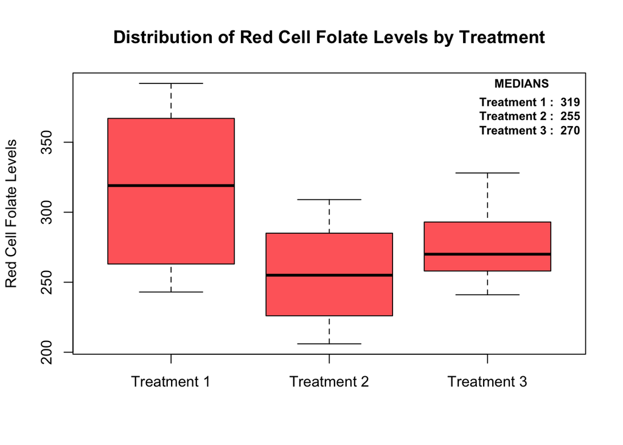

# Hypothesis

Global Null Hypothesis: There is no difference in folate levels between the three different treatments.

Alternative Hypothesis: There is a significant difference in means between at least on pair of treatments. _________________________________________________________________________________________________________________________

# One-way ANOVA test

The one-way ANOVA test resulted in a p-value of 0.0436. With it being lower than alpha level we can reject the null hypothesis. Although the p-value being relatively close to the alpha level gives us an indication that we should be looking at the differences in pairwise rather than as one group. Looking at the f-statistic, it furthers our information about the comparisons between groups. The larger the f-statistic the greater the variation between treatment means. If the null hypothesis were to be true, the f-statistic would be around 1.0, in this case ours is 3.711. All this being said we can perform a Bonferroni test to narrow down exactly which pairwise group is statistically significant.

```r
anova_test <- aov(folate ~ treatmnt, data = amess)

summary(anova_test)
```

```
##             Df Sum Sq Mean Sq F value Pr(>F)
## treatmnt     2  15516    7758   3.711 0.0436 *
## Residuals   19  39716    2090
## ---
## Signif. codes:  0 '***' 0.001 '**' 0.01 '*' 0.05 '.' 0.1 ' ' 1
```

P-value: 0.0436

F-Statistic: 3.711

# Bonferroni post-hoc test

This test allows us to obtain a clear picture of which pairwise differences are statistically significant. From the table, we observe that there are two pairs for which the p-values exceed above the 0.05 alpha level. The other pair has a p-value of 0.042, indicating that there is a statistical different between treatments 1 and 2. Based on this, we can reject the null hypothesis, as treatment 1 is statistically significant compared to 2.

```r
posthoc <- pairwise.t.test(amess$folate, amess$treatmnt, p.adjust.method = "bonferroni")

print(posthoc)
```

```
##
##  Pairwise comparisons using t tests with pooled SD
##
## data:  amess$folate and amess$treatmnt
##
##                                                50% N2O and 50% O2 continuously for 24 hours
## 50% N2O and 50% O2 during the operation        0.042
## No N2O but 35-50% O2 continuously for 24 hours 0.464
##                                                50% N2O and 50% O2 during the operation
## 50% N2O and 50% O2 during the operation        -
## No N2O but 35-50% O2 continuously for 24 hours 1.000
##
## P value adjustment method: bonferroni
```

P-values (pulled from table above):

Treatment 1 + Treatment 2: 0.042

Treatment 1 + Treatment 3: 0.464

Treatment 2 + Treatment 3: 1.00